# ET decay model

Beni Stocker

4/26/2019

## Linear model

- The initial water available to plants across the rooting zone, $S_0$ is 100 mm.
- ET (termed $T$, since it’s only transpiration here) is a linear function of the remaining water stored $S_t$ and is independent of VPD.
  $$T = \alpha S/S_0$$
- The change in plant-available water storage is $\Delta S=T$.

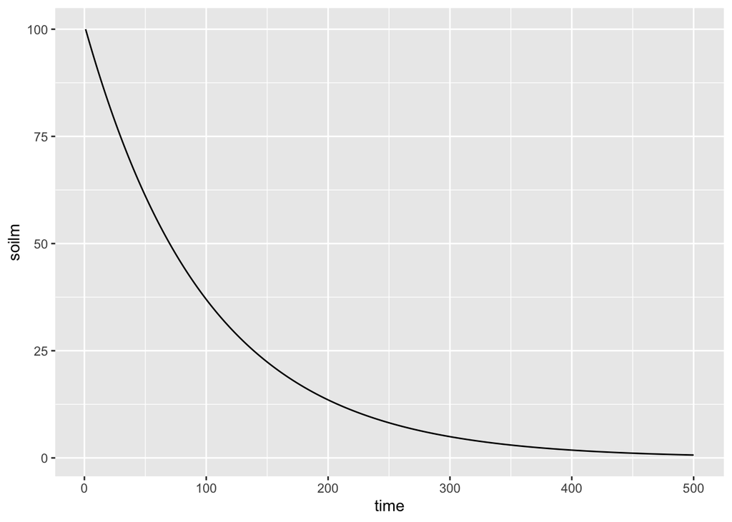

```r
s0 <- 100
alpha <- 1
ntsteps <- 500
s_t <- rep(NA, ntsteps)
t_t <- rep(NA, ntsteps)
s_t[1] <- s0

for (idx in 1:(ntsteps-1)){
  t_t[idx] <- alpha * s_t[idx] / s0
  s_t[idx + 1] <- s_t[idx] - t_t[idx]
}

df_lin <- tibble( time = 1:ntsteps, soilm = s_t, transp = t_t )

df_lin %>%
  ggplot(aes(time, soilm)) +
  geom_line()
```

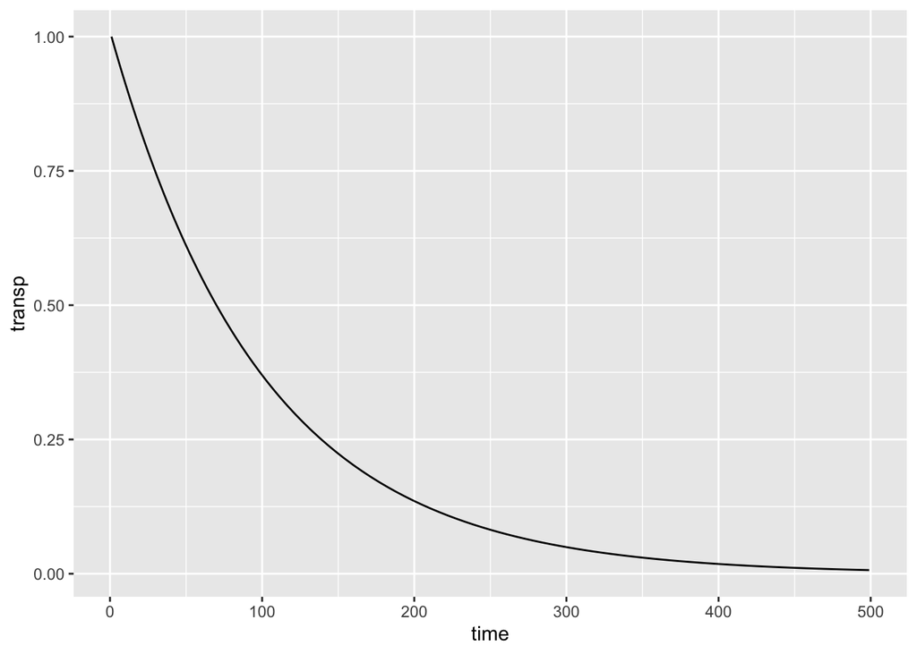

```r
df_lin %>%
  tidyr::drop_na() %>%
  ggplot(aes(time, transp)) +
  geom_line()
```

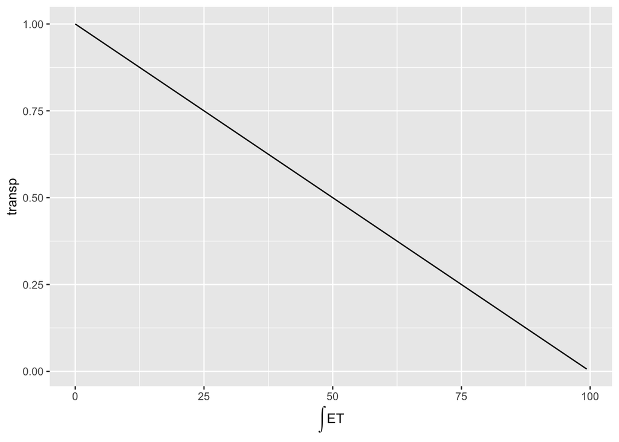

```r
df_lin %>%
  tidyr::drop_na() %>%
  ggplot(aes(100-soilm, transp)) +
  labs(x=expression(integral(ET))) +
  geom_line()
```

## Effect of rooting zone water storage capacity

Let’s compare the same relationship as above but with two different $S_0$.

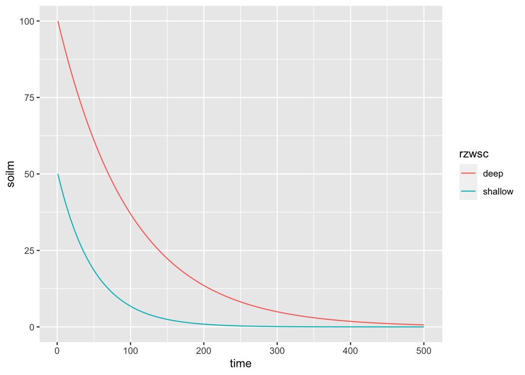

```r
s0 <- 50
s_t[1] <- s0
for (idx in 1:(ntsteps-1)){
  t_t[idx] <- alpha * s_t[idx] / s0
  s_t[idx + 1] <- s_t[idx] - t_t[idx]
}


df_lin_deep <- df_lin %>%
  mutate(rzwsc = "deep", cwd = cumsum(transp))

df_lin_shallow <- tibble(time = 1:ntsteps, soilm= s_t, transp = t_t) %>%
  mutate(rzwsc = "shallow", cwd = cumsum(transp))

df_lin <- bind_rows(df_lin_deep, df_lin_shallow)

df_lin %>%
  ggplot(aes(x = time, y = soilm, color = rzwsc)) +
  geom_line()
```

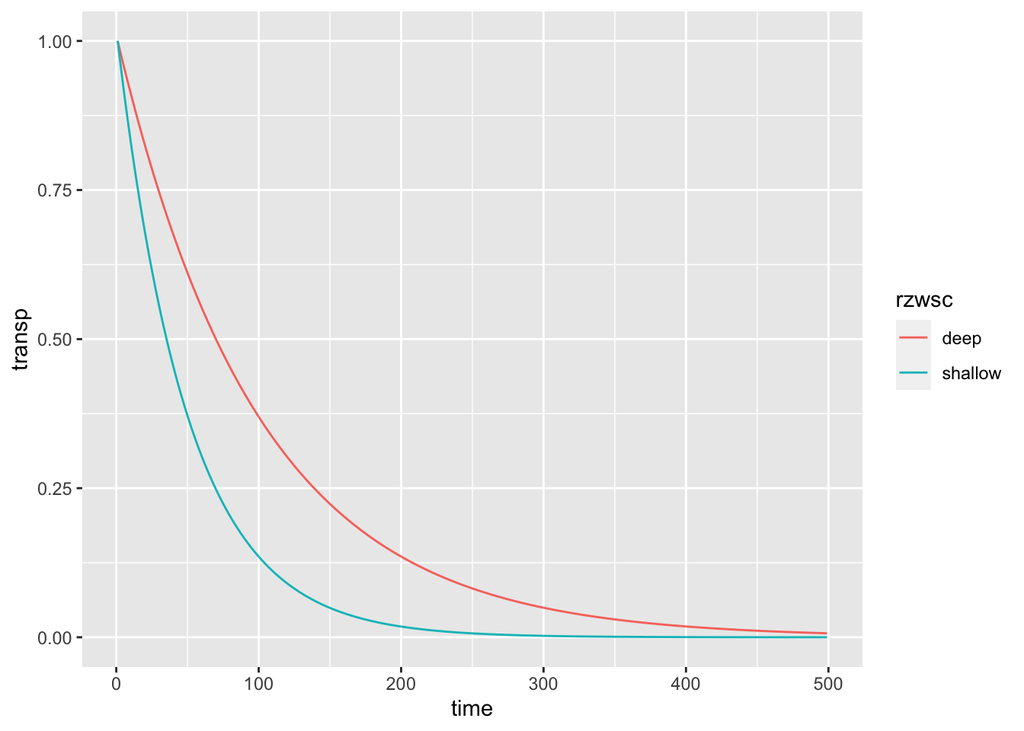

```r
df_lin %>%
  tidyr::drop_na() %>%
  ggplot(aes(time, transp, color = rzwsc)) +
  geom_line()
```

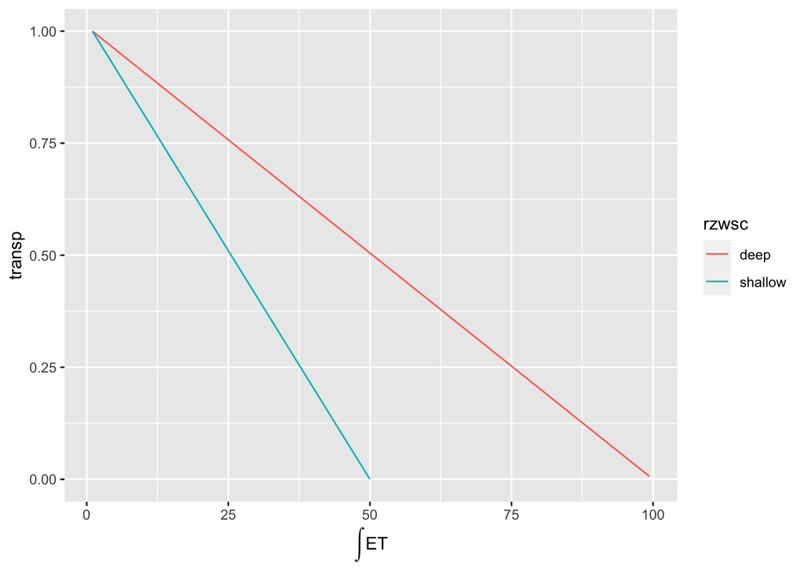

```r
df_lin %>%
  tidyr::drop_na() %>%
  ggplot(aes(x = cwd, y = transp, color = rzwsc)) +
  labs(x=expression(integral(ET))) +
  geom_line()
```

The question is: How does VPD affect the ET decline?

## VPD-enabled model, linear

We can formulate a model for $T$ as a function of VPD (termed $D$) and canopy conductance $G_s$.
$$T = G_s D$$
$G_s$ itself is a function of the remaining soil water content $S$. We can assume a linear model with $G_s = 0$ for $S = 0$:
$$G_s = \beta S$$
To get comparable numbers to the example above, let’s assume that under under well-watered conditions ($S = 100$ mm) and a VPD of 1000 Pa, we should have a transpiration of 1 mm d$^{-1}$. Hence, we $\beta = 10^{-5}$.
$$T = \beta S D$$

How does $T$ evolve under constant $D$?

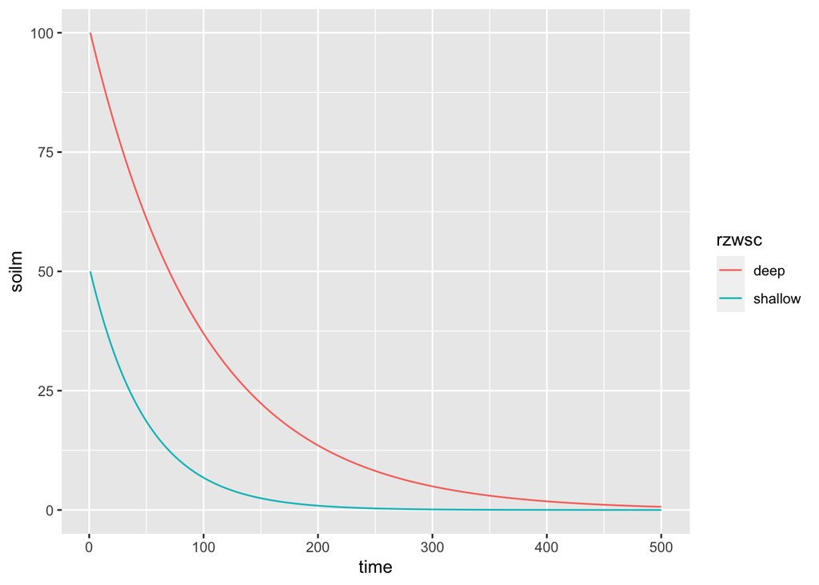

```r
## deep
s0 <- 100
alpha <- 1
ntsteps <- 500
d_t <- rep(1, ntsteps)
s_t <- rep(NA, ntsteps)
t_t <- rep(NA, ntsteps)
s_t[1] <- s0

for (idx in 1:(ntsteps-1)){
  t_t[idx] <- alpha * s_t[idx] * d_t[idx] / s0
  s_t[idx + 1] <- s_t[idx] - t_t[idx]
}

df_lin_deep <- tibble( time = 1:ntsteps, soilm = s_t, transp = t_t ) %>%
  mutate(rzwsc = "deep", cwd = cumsum(transp))


## shallow
s0 <- 50
s_t[1] <- s0
for (idx in 1:(ntsteps-1)){
  t_t[idx] <- alpha * s_t[idx] * d_t[idx] / s0
  s_t[idx + 1] <- s_t[idx] - t_t[idx]
}

df_lin_shallow <- tibble(time = 1:ntsteps, soilm= s_t, transp = t_t) %>%
  mutate(rzwsc = "shallow", cwd = cumsum(transp))

df_lin <- bind_rows(df_lin_deep, df_lin_shallow)

df_lin %>%
  ggplot(aes(x = time, y = soilm, color = rzwsc)) +
  geom_line()
```

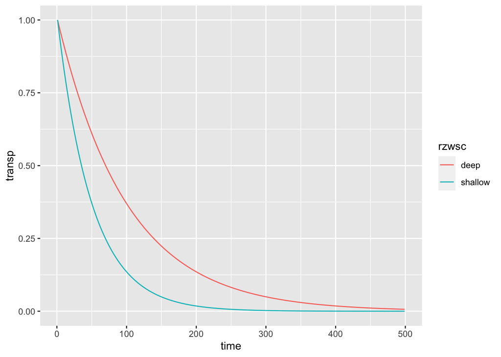

```r
df_lin %>%
  tidyr::drop_na() %>%
  ggplot(aes(time, transp, color = rzwsc)) +
  geom_line()
```

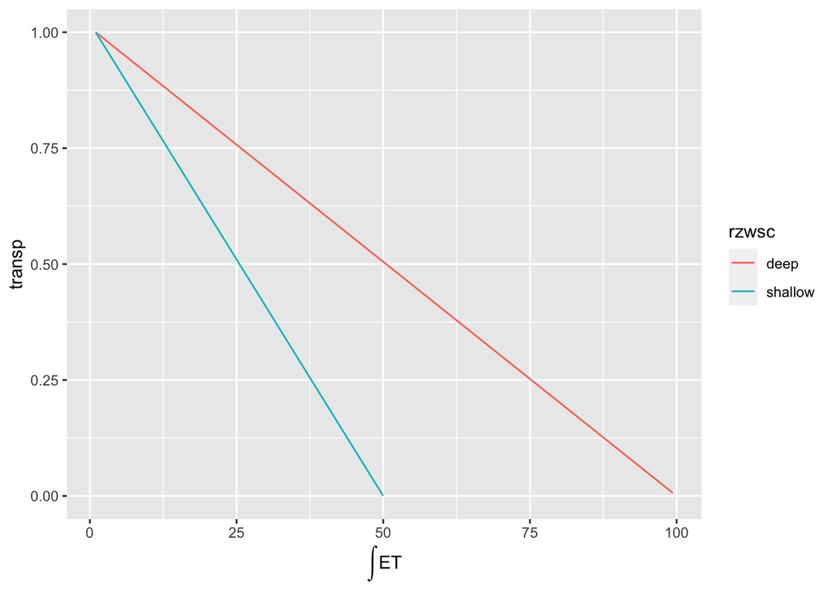

```r
df_lin %>%
  tidyr::drop_na() %>%
  ggplot(aes(x = cwd, y = transp, color = rzwsc)) +
  labs(x=expression(integral(ET))) +
  geom_line()
```

Ok. That’s the same. As expected because transpiration is effectively just a function of the $S$, equivalent to the linear model above.

But what happens when $D$ changes over time? Let’s assume a linear increase from 1000 Pa to 4000 Pa.

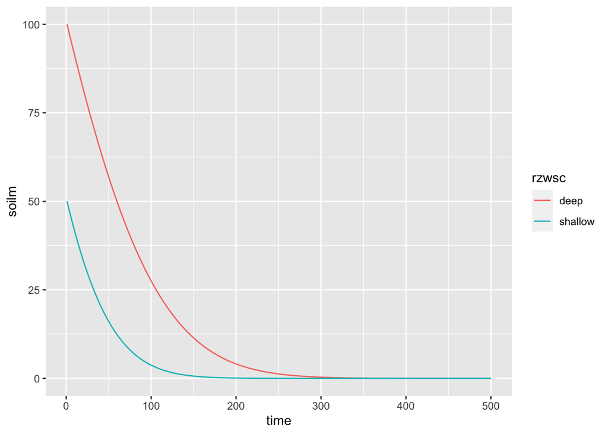

```r
## deep
s0 <- 100
alpha <- 1
ntsteps <- 500

d_t <- rep(NA, ntsteps)
d_t[1] <- 1
d_t[ntsteps] <- 4
d_t <- approx(1:ntsteps, d_t, xout=1:ntsteps)$y

s_t <- rep(NA, ntsteps)
t_t <- rep(NA, ntsteps)
s_t[1] <- s0

for (idx in 1:(ntsteps-1)){
  t_t[idx] <- alpha * s_t[idx] * d_t[idx] / s0
  s_t[idx + 1] <- s_t[idx] - t_t[idx]
}

df_lin_deep <- tibble( time = 1:ntsteps, soilm = s_t, transp = t_t ) %>%
  mutate(rzwsc = "deep", cwd = cumsum(transp))


## shallow
s0 <- 50
s_t[1] <- s0
for (idx in 1:(ntsteps-1)){
  t_t[idx] <- alpha * s_t[idx] * d_t[idx] / s0
  s_t[idx + 1] <- s_t[idx] - t_t[idx]
}

df_lin_shallow <- tibble(time = 1:ntsteps, soilm= s_t, transp = t_t) %>%
  mutate(rzwsc = "shallow", cwd = cumsum(transp))

df_lin <- bind_rows(df_lin_deep, df_lin_shallow)

df_lin %>%
  ggplot(aes(x = time, y = soilm, color = rzwsc)) +
  geom_line()
```

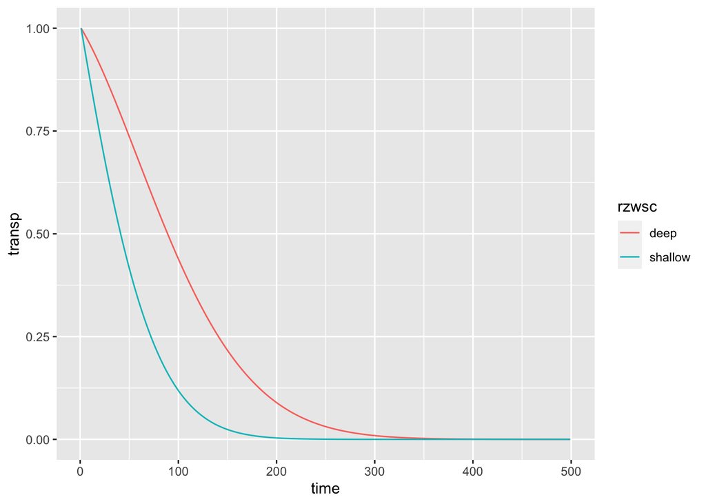

```r
df_lin %>%
  tidyr::drop_na() %>%
  ggplot(aes(time, transp, color = rzwsc)) +
  geom_line()
```

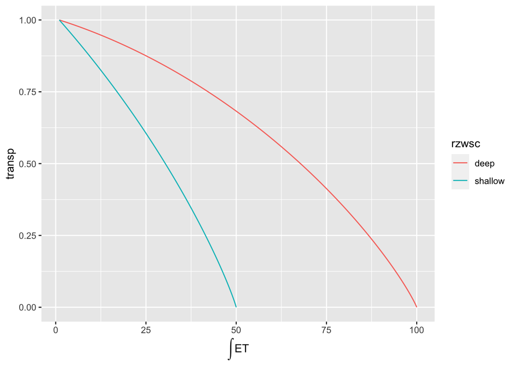

```r
df_lin %>%
  tidyr::drop_na() %>%
  ggplot(aes(x = cwd, y = transp, color = rzwsc)) +
  labs(x=expression(integral(ET))) +
  geom_line()
```

Hmmm. That’s not exactly the same.

## Gs a non-linear function of soil moisture

Instead of a linear response of $G_s$ to $S$, we can assume a sigmoidal response that looks (somewhat more realistically) like this:

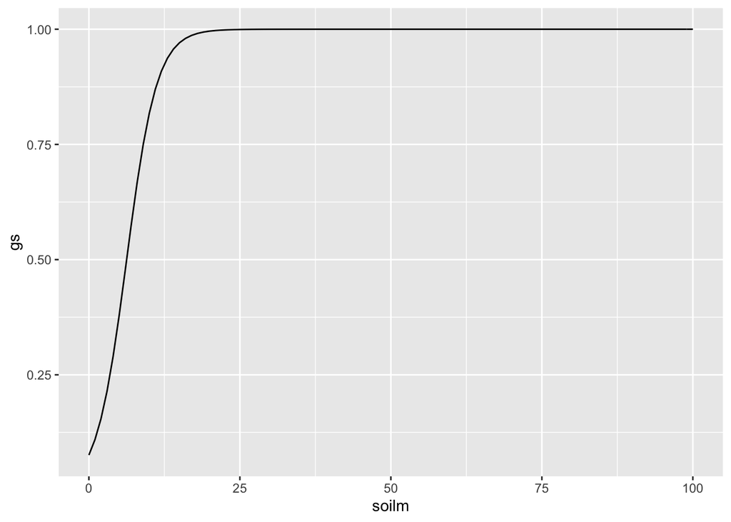

```r
sigm <- function(x){1/(1+exp(-(x/2.5-2.5)))}
df_sigm <- tibble(soilm=0:100) %>%
  rowwise() %>%
  mutate(gs = sigm(soilm))
df_sigm %>%
  ggplot(aes(soilm, gs)) +
  geom_line()
```

Now, let’s look at the evolution of soil moisture and transpiration during dry-down events. First, with constant VPD.

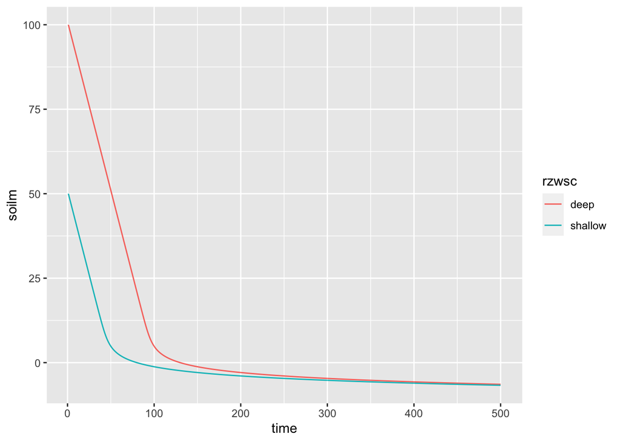

```r
## deep
s0 <- 100
alpha <- 1
ntsteps <- 500
d_t <- rep(1, ntsteps)
s_t <- rep(NA, ntsteps)
t_t <- rep(NA, ntsteps)
s_t[1] <- s0

for (idx in 1:(ntsteps-1)){
  t_t[idx] <- alpha * sigm(s_t[idx]) * d_t[idx]
  s_t[idx + 1] <- s_t[idx] - t_t[idx]
}

df_lin_deep <- tibble( time = 1:ntsteps, soilm = s_t, transp = t_t ) %>%
  mutate(rzwsc = "deep", cwd = cumsum(transp))

## shallow
s0 <- 50
s_t[1] <- s0
for (idx in 1:(ntsteps-1)){
  t_t[idx] <- alpha * sigm(s_t[idx]) * d_t[idx]
  s_t[idx + 1] <- s_t[idx] - t_t[idx]
}

df_lin_shallow <- tibble(time = 1:ntsteps, soilm= s_t, transp = t_t) %>%
  mutate(rzwsc = "shallow", cwd = cumsum(transp))

df_lin <- bind_rows(df_lin_deep, df_lin_shallow)

df_lin %>%
  ggplot(aes(x = time, y = soilm, color = rzwsc)) +
  geom_line()
```

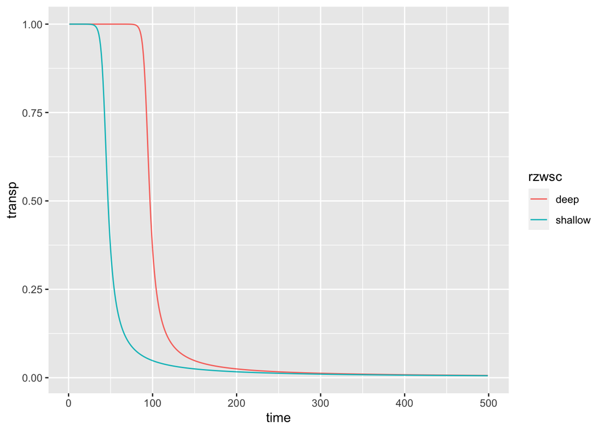

```r
df_lin %>%
  tidyr::drop_na() %>%
  ggplot(aes(time, transp, color = rzwsc)) +
  geom_line()
```

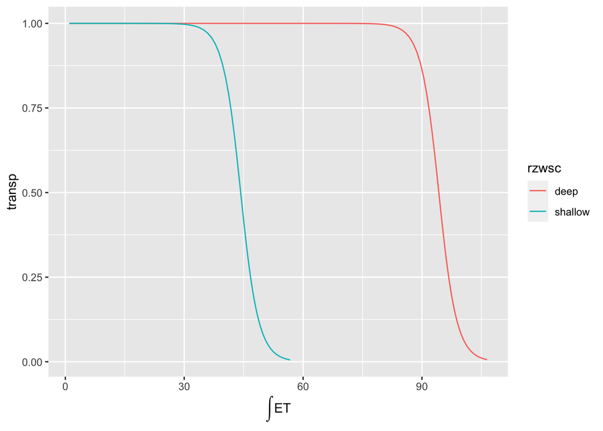

```r
df_lin %>%
  tidyr::drop_na() %>%
  ggplot(aes(x = cwd, y = transp, color = rzwsc)) +
  labs(x=expression(integral(ET))) +
  geom_line()
```